# HW7_Time Series Modeling Forecast

Yufei Liu

2025-11-20

## Series: Federal Reserve Z.1 — L.230 (Q), Nonfinancial corporate business; trade receivables; asset (FL103070005.Q).

# Setup

```r
library(readr)
library(forecast)
# file is in billions, quarterly, date like "YYYY Qn"
csv_path <- "C:/Users/l2007/Desktop/文档/Business Forecasting/Week 3/HW3 data_w SCFM project data/l230_nfc_trade_receivables_2000on.csv"

df <- read_csv(csv_path, show_col_types = FALSE)
names(df) <- tolower(names(df))

# parse "YYYY Qn", ts with frequency=4
parse_yq <- function(x){
  s <- gsub(" ", "", x)     # "YYYYQn"
  cbind(as.integer(substr(s,1,4)),
        as.integer(substr(s,nchar(s),nchar(s))))
}
yq <- parse_yq(df$date)
y_ts <- ts(df$value, start = c(yq[1,1], yq[1,2]), frequency = 4)

H <- frequency(y_ts)
```

# Plot Time Series

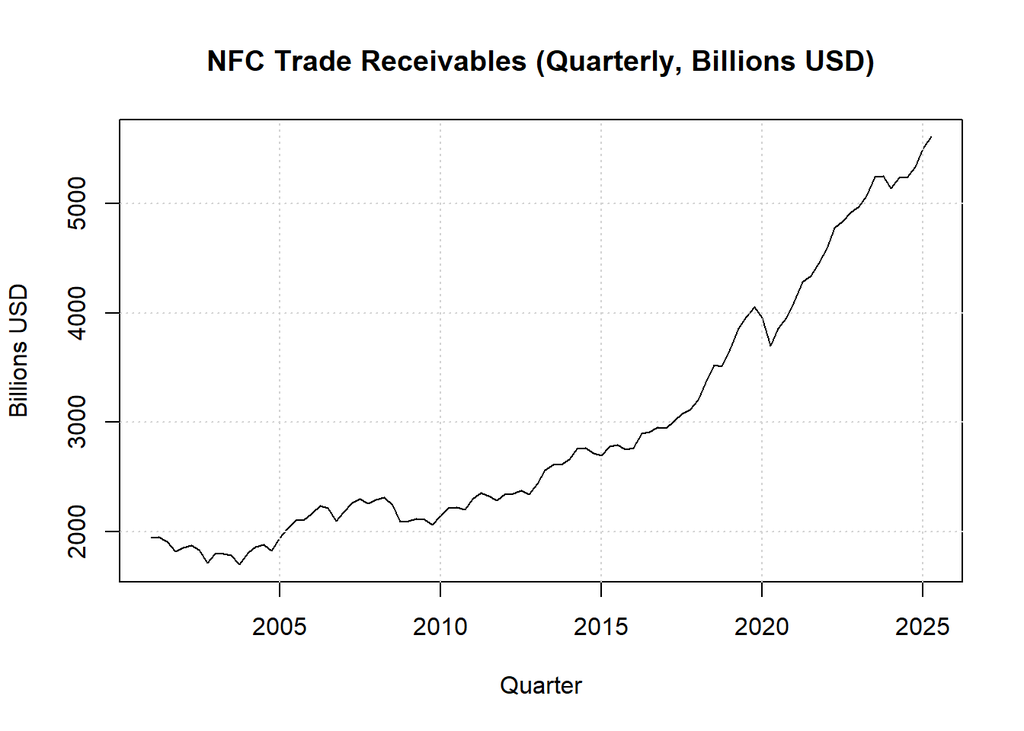

```r
plot(y_ts, main = "NFC Trade Receivables (Quarterly, Billions USD)",
ylab = "Billions USD", xlab = "Quarter", lwd = 1)
grid()
```

• Please summarize your observations of the time series plot 1. The overall trend is clear upward. The level climbed fast through 2010 to 2019. There is one obvious shock around 2020. May caused by the pandemic. Then, the trend has risen the fastet since 2021. 2. Seasonality looks weak. I don’t see a stable, repeating pattern in the plot. Comparing to the overall trend, wiggles between quarters are small relative. 3. Current level is the highest.

# ARIMA

## Identify differencing + Explain the model output

```r
# same tools as notes
d  <- ndiffs(y_ts)       # non-seasonal differences needed
D  <- nsdiffs(y_ts)      # seasonal differences at lag 4
d
```

```
## [1] 2
```

```r
D
```

```
## [1] 0
```

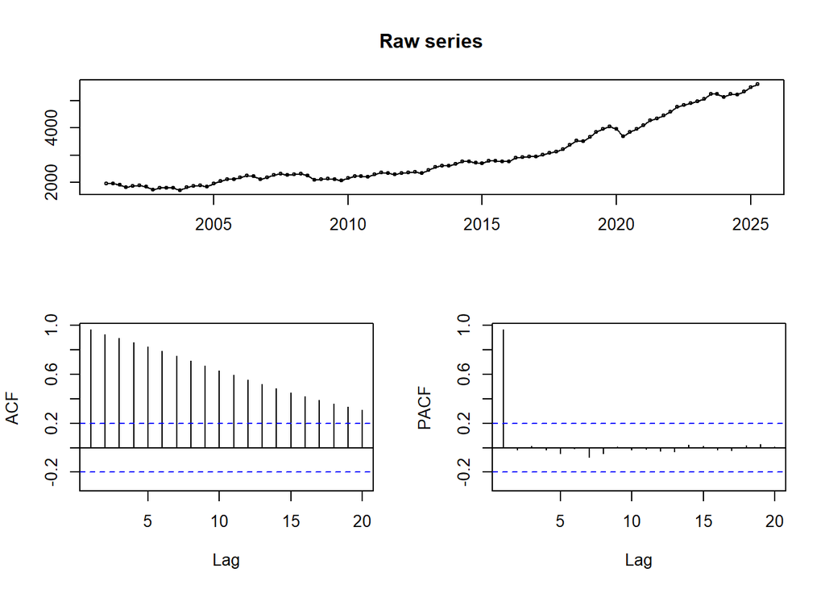

```r
# show ACF/PACF
tsdisplay(y_ts, main = "Raw series")
```

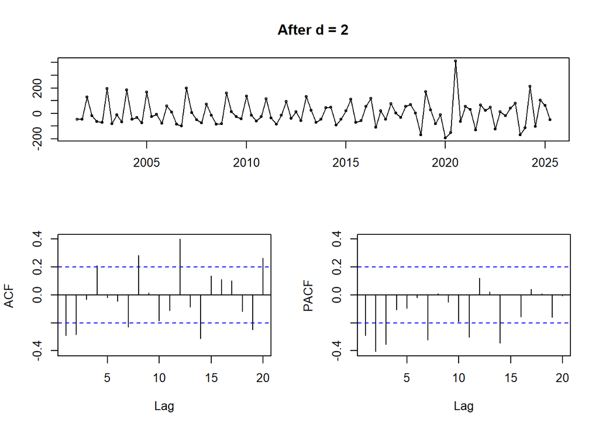

```r
if (d > 0) tsdisplay(diff(y_ts, differences = d), main = paste("After d =", d))
```

```r
if (D > 0) tsdisplay(diff(y_ts, lag = 4, differences = 1), main = "After seasonal D = 1")

# fit
auto_fit <- auto.arima(y_ts, stepwise = FALSE, approximation = FALSE, seasonal = TRUE)
auto_fit
```

```
## Series: y_ts
## ARIMA(0,2,2)(1,0,2)[4]
##
## Coefficients:
##           ma1      ma2    sar1     sma1    sma2
##       -0.6976  -0.2686  0.9605  -0.9806  0.1880
## s.e.   0.0955   0.0953  0.0368   0.1194  0.1072
##
## sigma^2 = 4832:  log likelihood = -543.12
## AIC=1098.25   AICc=1099.19   BIC=1113.63
```